# WILD 591 – Spatial Population Modeling

Lesson 10: Spatial Occupancy Models

Mahdieh Tourani

2026-10-16

# Where we’re going

## Roadmap for today

1. Occupancy framework
2. Spatial dynamic occupancy
3. Spatial co-occurrence model
4. Spatial dynamic co-ocurrence model

# 1.1 Population modeling background

## Structured populations

> Populations, i.e., collections of interacting organisms of the same species, have a variety of structures.
- Sexes: female and male
- Ages: newborn, yearlings, juveniles, adults
- Spatial and dynamic

## Demography

$$\Delta N = B + I - D - E$$

Spatially structured population dynamics and underlying prcesses are driven by heterogeneity and dynamics of abiotic, as well as intra- and inter-specific interactions.

[figure not shown]

## Previously

> Metapopulation is defined as a set of connected local populations that persist in a balance between local extinctions and colonization.

The concept has been generalized to any spatially structured population that inhabits heterogeneous habitats.

- As oposed to classic metapopulation models, modern statistical models account for imperfect detection.

# 1.2 Occupancy framework

## Imperfect Detection

- **Raw Observations vs Latent Reality**:
  - $y_{ijt} = 0$ can mean **True Absence** ($z_{it} = 0$) OR **Non-Detection** ($z_{it} = 1, p < 1$).
  - Naive raw proportion of occupied sites ($\hat{\psi}_{\text{naive}}$) severely underestimates true occupancy.
- **False Negative Probability**: $(1 - p)^J$, where $J$ is the number of secondary visits.
- **Biological Consequence**: Masking population declines, range contractions, and extinction events.

## Static Occupancy Model

- **Process Sub-model**:
  $$z_i \sim \text{Bernoulli}(\psi_i), \quad \text{logit}(\psi_i) = \mathbf{X}_i \boldsymbol{\beta}$$
- **Observation Sub-model**:
  $$y_{ij} | z_i \sim \text{Bernoulli}(z_i p_{ij}), \quad \text{logit}(p_{ij}) = \mathbf{W}_{ij} \boldsymbol{\alpha}$$
- **Assumptions**:
  1. Closure: Occupancy state $z_i$ is constant across $j = 1, \dots, J$ visits.
  2. Independence of detections conditional on $z_i$.
  3. No false positives ($P(y=1 | z=0) = 0$).

## Dynamic Occupancy Model

- **Initial State** ($t = 1$):
  $$z_{i,1} \sim \text{Bernoulli}(\psi_{i,1})$$
- **State Transitions** ($t > 1$):
  $$z_{i,t} | z_{i,t-1} \sim \text{Bernoulli}\left( z_{i,t-1} \phi_{i,t-1} + (1 - z_{i,t-1}) \gamma_{i,t-1} \right)$$
- **Parameters**:
  - $\psi_1$: Initial occupancy probability
  - $\phi_{i,t-1}$: Persistence probability ($1 - \epsilon_{i,t-1}$)
  - $\gamma_{i,t-1}$: Colonization probability
- **Observation submodel** for primary period $t$ and secondary visit $j \in \{1, \dots, J_{i,t}\}$:
  $$y_{ijt} | z_{it} \sim \text{Bernoulli}(z_{it} p_{ijt})$$

## Where to from here

- Static occupancy models consider neither space nor time
- Dynamic occupancy models consider the temporal aspect but not spatial dependence between sites
- Co-occurrence models

# 2.1 Spatial Dynamic Occupancy Models

## Spatial component

- **Non-Spatial Limitation**: classic dynamic occupancy assumes colonization $\gamma_{it}$ is independent of occupancy at neighboring sites.
- **Spatial Autocorrelation in Dynamics**:
  - A site near occupied sites has a higher colonization probability.
- **Spatial Colonization Model**:
  $$z_{i,1} \sim \text{Bernoulli}(\psi_{i,1})$$
  $$z_{i,t} | z_{i,t-1} \sim \text{Bernoulli}\left( z_{i,t-1} \phi_{i,t-1} + (1 - z_{i,t-1}) \gamma_{i,t-1} \right)$$
  $$\gamma_{i,t-1} = f\left( \mathbf{X}_i, \text{Connectivity}(i, \mathbf{z}_{t-1}) \right)$$

## Autologistic model: Logit-linear

Colonization/persistence at site *i* is a function of site *i*’s neighborhood, i.e., how much of site *i*’s neighbourhood was occupied last year.

- **Logit-linear Autocovariate**:
  $$\begin{aligned}
  \color{#0d5f55}{A_{i,t-1}} &\color{#0d5f55}{= \frac{1}{n_i}\sum_{j \sim i} z_{j,t-1}}
  && \text{}\\[6pt]
  \text{logit}(\gamma_{i,t-1}) &= a^{\gamma}_0 + a^{\gamma}_1 x_i + \color{#0d5f55}{b^{\gamma}\, A_{i,t-1}}\\[6pt]
  \end{aligned}$$

$n_i$: Number of neighbours of site $i$ (3, 5 or 8 on a square grid with a queen’s neighbourhood).

$A_{i,t-1}$: The *proportion* of site $i$’s neighbours that were occupied in year $t-1$.

$b^{\gamma}$: Effect of that local density on colonisation, on the logit scale. Positive $b^{\gamma}$ is the signature of distance-limited spread.

$a^{\gamma}_0$ : Baseline colonisation when no neighbours are occupied — i.e. long-distance colonisation from outside the neighbourhood.

## Autologistic model: adjacency indicator

- **Autologistic Transition Form**:
  $$\gamma_{i,t-1} \;=\; 1 \;-\; \big(1-\zeta\big)^{\textstyle\sum_{i'} a_{i,i'}\, z_{i',t-1}} \times \big(1-\delta\big)$$
  $a_{i,i'}$: Binary adjacency indicator, 1 if sites $i$ and $i'$ are adjacent, 0 otherwise.

$\zeta$: Probability of colonisation contributed by **one** occupied neighbour.

$\delta$: Probability of colonisation from **non-adjacent** sites (long-distance movement)

## Distance-Based Movement

- The definition of adjacency can be arbitrary if sites are not naturally adjacent to each other in patchy habitats.
- It may be an oversimplification to assume that only adjacent sites are connected.
- More realistic to assume that connectivity between two sites is related to their distance, typically with a negative relationship.

## Distance-Based Dispersal Kernels

- **Standardized Connectivity Weight**:
  $$\begin{aligned}
  \color{#0d5f55}{\eta_{i,i'}} &\color{#0d5f55}{= \exp\!\left(-\kappa\, d_{i,i'}\right)}
  && \text{unstandardised colonisation rate}\\[6pt]
  \color{#0d5f55}{\theta_{i,i'}} &\color{#0d5f55}{= \frac{\eta_{i,i'}}{\sum_{i''=1}^{M}\eta_{i,i''}}}
  && \text{standardised colonisation rate}\\[6pt]
  \end{aligned}$$

$d_{i,i'}$: Distance between sites $i$ and $i'$. Note $d_{i,i} = 0$, so a site contributes to itself with weight $\eta = 1$.

$\kappa$: **Decay parameter**. Large $\kappa$ means colonisation falls off fast with distance — a poor disperser. $\kappa \to 0$ means every site contributes equally and space stops mattering.

$\eta_{i,i'}$: Raw kernel weight, in $(0,1]$. Equals 1 at zero distance.  
$\theta_{i,i'}$: Kernel weight normalised so that $\sum_{i'} \theta_{i,i'} = 1$ for every $i$.

$\gamma_{i,t-1}$: Colonisation probability — a **weighted average of the occupancy states**, with weights that decay with distance.

- **Colonization Probability**:
  $$\gamma_{i, t-1} = \sum_{i'=1}^{M} \theta_{i,i'}\, z_{i',t-1}$$

## Combined Distance- and Environment-Based Movement

- Dispersal depends on both geographic distance $d_{i,i'}$ AND habitat quality at source/target sites:

$$\begin{aligned}
\color{#0d5f55}{\gamma_{i,t-1}} &\color{#0d5f55}{=
\underbrace{\text{logit}^{-1}\!\left(\beta^{[\gamma]}_0 + \beta^{[\gamma]}_1 x_{i,t,1} + \dots\right)}_{\text{local suitability}}
\;\times\;
\underbrace{\sum_{i'=1}^{M}\theta_{i,i'}\, z_{i',t-1}}_{\text{connectivity}}}\\[8pt]
\theta_{i,i'} &= \frac{\eta_{i,i'}}{\sum_{i''}\eta_{i,i''}}, \qquad
\eta_{i,i'} = \exp(-\kappa\, d_{i,i'})
\end{aligned}$$
**Local suitability**: how good a destination site $i$ is, given its own covariates.

**Connectivity**: how much occupied habitat is within dispersal reach.

# 2.2 Spatial Co-occurrence Model

## Co-occurrence

Coexistence of interacting species has long been a focus in metapopulation studies (Hanski and Gilpin 1997; Hanski 1998)

- Occupancy status of a species is influenced by its abiotic environment and the presence or absence of other interacting species.
- Species colonization/persistence is influenced by its abiotic environment and the presence or absence of other interacting species.

## Spatial Dynamic Co-occurrence Model

- **Interspecific Interactions**: Modeling co-occurrence dynamics of species $s \in \{1, \dots, S\}$.
- **Latent States**: $z_{i,t,s} \in \{0, 1\}$ for species $s$ at site $i$, year $t$.
- **Interaction Mechanisms**:
  - Predator presence ($z_{i,t-1, \text{pred}} = 1$) reduces prey persistence $\phi_{i,t-1,\text{prey}}$ and colonization $\gamma_{i,t-1,\text{prey}}$.
  - Prey presence increases predator persistence and colonization.

## Predator-Prey Prsistence

- **Prey Persistence**:
  $$\text{logit}(\phi_{i,t-1,\text{prey}}) = \beta_0^{(\phi,\text{prey})} + \beta_{\text{pred}}^{(\phi,\text{prey})} \times z_{i,t-1,\text{pred}} + \mathbf{X}_i \boldsymbol{\beta}$$
- **Predator Persistence**:
  $$\text{logit}(\phi_{i,t-1,\text{pred}}) = \beta_0^{(\phi,\text{pred})} + \beta_{\text{prey}}^{(\phi,\text{pred})} \times z_{i,t-1,\text{prey}} + \mathbf{X}_i \boldsymbol{\beta}$$
- Expected Signs: $\beta_{\text{pred}}^{(\phi,\text{prey})} < 0$ (prey suppressed) and $\beta_{\text{prey}}^{(\phi,\text{pred})} > 0$ (predator supported).

## Case Study: Ant vs Butterfly Meadow Metapopulation

- **System**: Invasive ant (*Myrmica*) vs native lycaenid butterfly.
- **Hypothesis**: Ant presence induces local extinction of butterfly caterpillar patches.
- **Dynamic Occupancy Estimates**:
  - Butterfly persistence $\phi_{\text{butterfly}}$ drops from $0.85$ (ant absent) to $0.22$ (ant present).
  - Butterfly colonization $\gamma_{\text{butterfly}}$ reduced by $65\%$ in ant-dominated meadows.

# 3.1 Simulations

## Simulate the orchid network

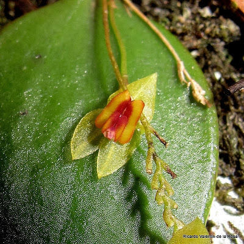

```r
set.seed(1010)
n_p <- 841                        # patches

# patches scatter along a sinuous river channel, in metres
tt <- sort(runif(n_p, 0, 1))
rx <- 300 * tt + rnorm(n_p, 0, 6)
ry <- -300 * tt + 40 * sin(8 * tt) + rnorm(n_p, 0, 6)
rz <- 60 * tt + rnorm(n_p, 0, 2)          # elevation gradient along the river

area <- round(rlnorm(n_p, log(35), 1.0), 1)     # moss area, cm2
area <- pmin(area, 650)

# 3-D distance
dmat <- as.matrix(dist(cbind(rx, ry, rz)))

meandist <- 4.8             # mean seed dispersal, m (Tremblay 1997)
alpha <- 1 / meandist

plot(rx,
     ry,
     pch = 21,
     bg = "grey85",
     cex = log(area + 1) / 3,
     xlab = "x (m)",
     ylab = "y (m)",
     asp = 1,
     main = "841 moss patches along the river; symbol size ~ log(area)")
c(patches = n_p,
  mean_area = round(mean(area), 1),
  max_area = max(area),
  alpha = round(alpha, 3))
```

[output not shown]

## Simulate occupancy dynamics

```r
# TRUTH
b_psi   <- c(int = -2.899, area = 0.562, S = 0.185)
b_eps   <- c(int = -1.21,  area = -0.62)
logit_g <- -4.14                       # colonization, constant
p_det   <- 0.843                       # per-survey detection

n_prim <- 5; n_sec <- 2
logarea <- log(area + 1)

# connectivity S_i, ignoring occupancy
gker <- exp(-alpha * dmat); diag(gker) <- 0
S <- as.vector(gker %*% area)
Sz <- as.numeric(scale(S))             # centres and scales S

psi1 <- plogis(b_psi["int"] + b_psi["area"] * logarea + b_psi["S"] * Sz)
eps  <- plogis(b_eps["int"] + b_eps["area"] * logarea)
gam  <- plogis(logit_g)

set.seed(1011)
z <- matrix(NA_integer_, n_p, n_prim)
z[, 1] <- rbinom(n_p, 1, psi1)
for (t in 2:n_prim) {
  pr <- z[, t - 1] * (1 - eps) + (1 - z[, t - 1]) * gam
  z[, t] <- rbinom(n_p, 1, pr)
}

# observation: two secondary surveys per primary period
y <- matrix(NA_integer_, n_p, n_prim * n_sec)
for (t in 1:n_prim) for (j in 1:n_sec) {
  y[, (t - 1) * n_sec + j] <- rbinom(n_p, 1, z[, t] * p_det)
}

# Counts as well as occupancy: holds abundance N, and
# the synchrony analysis needs a series with variance. A purely binary series
# from a patch that never changes state has sd = 0.
lamN <- exp(0.4 + 0.35 * logarea)          # expected count when occupied
N <- matrix(0L, n_p, n_prim)
for (t in 1:n_prim) N[, t] <- as.integer(z[, t] * rpois(n_p, lamN))

c(ever_occupied_true = sum(rowSums(z) > 0),
  ever_detected = sum(rowSums(y) > 0),
  detections = sum(y), non_detections = sum(y == 0),
  detection_rate = round(mean(y), 3),
  psi_star_expected = round(mean(gam / (gam + eps)), 3),
  mean_count_when_occupied = round(mean(N[z == 1]), 1))
```

[output not shown]

```r
library(unmarked)
site_cov <- data.frame(logarea = logarea, Sz = Sz)

# a survey-level covariate: day of year, standardised
set.seed(1012)
date_mat <- matrix(scale(as.vector(
  outer(rep(1, n_p), rep(c(40, 210), n_prim)) + rnorm(n_p * n_prim * n_sec, 0, 8)
))[, 1], n_p, n_prim * n_sec)

# implicit-dynamics frame: stack primary periods as if independent
y_stack   <- do.call(rbind, lapply(1:n_prim,
                     function(t) y[, (t - 1) * n_sec + 1:n_sec]))
cov_stack <- do.call(rbind, replicate(n_prim, site_cov, simplify = FALSE))
dat_stack <- do.call(rbind, lapply(1:n_prim,
                     function(t) date_mat[, (t - 1) * n_sec + 1:n_sec]))

umf_occ <- unmarkedFrameOccu(y = y_stack, siteCovs = cov_stack,
                             obsCovs = list(date = dat_stack))

# dynamic frame: all 10 surveys, 5 primary periods
umf_dyn <- unmarkedMultFrame(y = y, siteCovs = site_cov,
                             obsCovs = list(date = date_mat),
                             numPrimary = n_prim)
c(stacked_rows = nrow(y_stack), dynamic_sites = numSites(umf_dyn))
```

[output not shown]

# 3.2 Fit occupancy models

## First, ignore the dynamics

```r
m_p_null <- occu(~ 1 ~ 1, umf_occ)
m_p_date <- occu(~ date ~ 1, umf_occ)
m_p_both <- occu(~ date + logarea ~ 1, umf_occ)

modSel(fitList(fits = list("p(.)" = m_p_null,
                           "p(date)" = m_p_date,
                           "p(date+area)" = m_p_both)))
```

[output not shown]

## Now add area and isolation

```r
m_area   <- occu(~ date + logarea ~ logarea, umf_occ)
m_S      <- occu(~ date + logarea ~ Sz, umf_occ)
m_areaS  <- occu(~ date + logarea ~ logarea + Sz, umf_occ)

modSel(fitList(fits = list("psi(.)" = m_p_both,
                           "psi(area)" = m_area,
                           "psi(S)" = m_S,
                           "psi(area+S)" = m_areaS)))
round(coef(m_areaS), 3)
```

[output not shown]

## Colonization and extinction, explicitly

```r
m_dyn_null <- colext(psiformula = ~ 1,
                     gammaformula = ~ 1,
                     epsilonformula = ~ 1,
                     pformula = ~ 1,
                     data = umf_dyn)

m_dyn_psi  <- colext(psiformula = ~ logarea + Sz,
                     gammaformula = ~ 1,
                     epsilonformula = ~ 1,
                     pformula = ~ 1,
                     data = umf_dyn)

m_dyn_eps  <- colext(psiformula = ~ logarea + Sz,
                     gammaformula = ~ 1,
                     epsilonformula = ~ logarea,
                     pformula = ~ 1,
                     data = umf_dyn)

m_dyn_full <- colext(psiformula = ~ logarea + Sz,
                     gammaformula = ~ Sz,
                     epsilonformula = ~ logarea,
                     pformula = ~ 1,
                     data = umf_dyn)

modSel(fitList(fits = list("null" = m_dyn_null,
                           "psi(area+S)" = m_dyn_psi,
                           "psi(area+S) eps(area)" = m_dyn_eps,
                           "+ gamma(S)"           = m_dyn_full)))
```

[output not shown]

## Did it recover the truth?

```r
est <- coef(m_dyn_eps)

# coef() for a colext fit returns psi, then col, then ext, then det. This
# vector is in that order -- READ THE PRINTED NAMES to confirm rather than
# trusting the order, and the stopifnot catches a length mismatch.
truth_vec <- c(b_psi[["int"]],
               b_psi[["area"]],
               b_psi[["S"]],   # psi
               logit_g,          # col
               b_eps[["int"]],
               b_eps[["area"]],  # ext
               qlogis(p_det))     # det
stopifnot(length(est) == length(truth_vec))

data.frame(parameter  = names(est),
           estimate   = round(as.numeric(est), 3),
           truth      = round(truth_vec, 3),
           difference = round(as.numeric(est) - truth_vec, 3))

round(c(gamma = backTransform(m_dyn_eps, type = "col")@estimate,
        p     = backTransform(m_dyn_eps, type = "det")@estimate), 4)
```

[output not shown]

## Partial predictions

```r
ar_seq <- seq(min(logarea), max(logarea), length.out = 60)
S_seq  <- seq(min(Sz), max(Sz), length.out = 60)

nd_area <- data.frame(logarea = ar_seq, Sz = mean(Sz))
nd_S    <- data.frame(logarea = mean(logarea), Sz = S_seq)

# NOTE: predict(object, type, newdata) -- name BOTH, the 2nd positional is type
pr_psi_a <- predict(m_dyn_eps, type = "psi", newdata = nd_area)
pr_psi_S <- predict(m_dyn_eps, type = "psi", newdata = nd_S)
pr_ext_a <- predict(m_dyn_eps, type = "ext", newdata = nd_area)

band <- function(x, p, xlab, ylab, main, truth = NULL) {
  plot(x, p$Predicted, type = "l", lwd = 3, ylim = c(0, 1),
       xlab = xlab, ylab = ylab, main = main)
  lines(x, p$lower, lty = 2); lines(x, p$upper, lty = 2)
  if (!is.null(truth)) lines(x, truth, col = "firebrick", lwd = 2.4, lty = 3)
}

op <- par(mfrow = c(1, 3), mar = c(4.4, 4.6, 3, 1))
band(exp(ar_seq) - 1, pr_psi_a, "patch area (cm2)", "initial occupancy",
     "psi vs area",
     plogis(b_psi["int"] + b_psi["area"] * ar_seq + b_psi["S"] * mean(Sz)))
band(S_seq, pr_psi_S, "connectivity S (scaled)", "", "psi vs S",
     plogis(b_psi["int"] + b_psi["area"] * mean(logarea) + b_psi["S"] * S_seq))
band(exp(ar_seq) - 1, pr_ext_a, "patch area (cm2)", "extinction",
     "extinction vs area",
     plogis(b_eps["int"] + b_eps["area"] * ar_seq))
par(op)
```

[output not shown]

# 3.3 Project forward

## Project the fitted dynamics

```r
nd_fit  <- data.frame(logarea = logarea, Sz = Sz)
psi_hat <- predict(m_dyn_eps, type = "psi", newdata = nd_fit)$Predicted
col_hat <- predict(m_dyn_eps, type = "col", newdata = nd_fit)$Predicted
ext_hat <- predict(m_dyn_eps, type = "ext", newdata = nd_fit)$Predicted

colext_sim <- function(psi0, col, ext, timeframe, reps) {
  ns <- length(psi0)
  out <- array(NA_integer_, dim = c(reps, ns, timeframe))
  out[, , 1] <- rbinom(reps * ns, 1, rep(psi0, each = reps))
  for (t in 2:timeframe) {
    prev <- out[, , t - 1]
    pr <- prev * (1 - rep(ext, each = reps)) +
          (1 - prev) * rep(col, each = reps)
    out[, , t] <- rbinom(reps * ns, 1, pr)
  }
  out
}

set.seed(1013)
proj <- colext_sim(psi_hat, col_hat, ext_hat, timeframe = 100, reps = 20)
land_mean <- apply(proj, c(1, 3), mean)          # reps x time

psi_star <- mean(col_hat / (col_hat + ext_hat))

op <- par(mar = c(4.4, 4.6, 3, 1))
matplot(t(land_mean), type = "l", lty = 1, col = rgb(0, 0, 0, 0.25),
        ylim = c(0, 0.6), xlab = "time step",
        ylab = "proportion of patches occupied",
        main = "100-year projection, 20 realizations")
lines(colMeans(land_mean), lwd = 3, col = "steelblue")
abline(h = psi_star, lwd = 2.5, lty = 2, col = "firebrick")
text(80, psi_star + 0.03, expression(psi^"*"), col = "firebrick", cex = 1.3)
par(op)
round(c(psi_star = psi_star, projected_end = mean(land_mean[, 100])), 3)
```

[output not shown]